# Exercise 7 - Unsupervised Learning

Ken Benoit and Slava Mikhaylov

### Exercise 7.1

Consider the `USArrests` data. We will now perform hierarchical clustering on the states.

```r
library(ISLR)
set.seed(2)
```

1. Using hierarchical clustering with complete linkage and Euclidean distance, cluster the states.

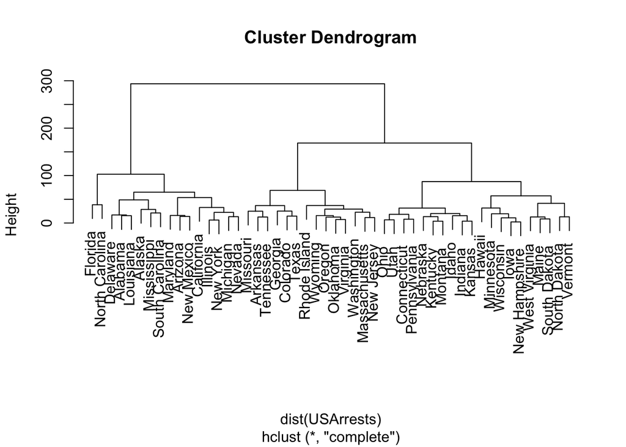

```r
hc.complete <-  hclust(dist(USArrests), method="complete")
plot(hc.complete)
```

2. Cut the dendrogram at a height that results in three distinct clusters. Which states belong to which clusters?

```r
cutree(hc.complete, 3)
```

```
##        Alabama         Alaska        Arizona       Arkansas     California
##              1              1              1              2              1
##       Colorado    Connecticut       Delaware        Florida        Georgia
##              2              3              1              1              2
##         Hawaii          Idaho       Illinois        Indiana           Iowa
##              3              3              1              3              3
##         Kansas       Kentucky      Louisiana          Maine       Maryland
##              3              3              1              3              1
##  Massachusetts       Michigan      Minnesota    Mississippi       Missouri
##              2              1              3              1              2
##        Montana       Nebraska         Nevada  New Hampshire     New Jersey
##              3              3              1              3              2
##     New Mexico       New York North Carolina   North Dakota           Ohio
##              1              1              1              3              3
##       Oklahoma         Oregon   Pennsylvania   Rhode Island South Carolina
##              2              2              3              2              1
##   South Dakota      Tennessee          Texas           Utah        Vermont
##              3              2              2              3              3
##       Virginia     Washington  West Virginia      Wisconsin        Wyoming
##              2              2              3              3              2
```

```r
table(cutree(hc.complete, 3))
```

```
##
##  1  2  3
## 16 14 20
```

3. Hierarchically cluster the states using complete linkage and Euclidean distance, after scaling the variables to have standard deviation one.

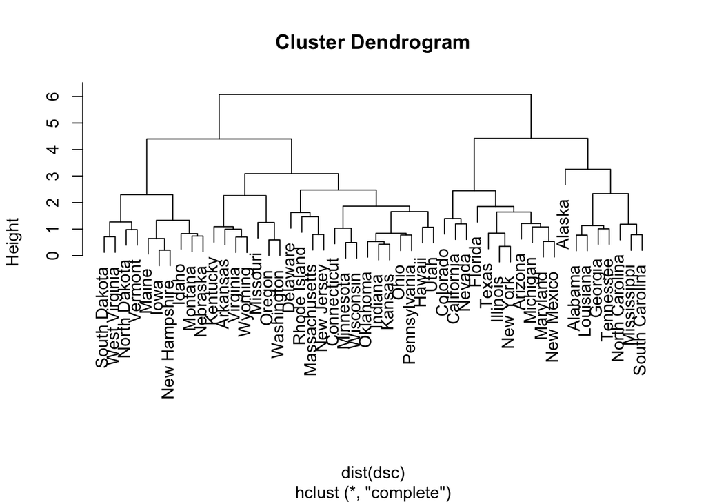

```r
dsc <-  scale(USArrests)
hc.s.complete <-  hclust(dist(dsc), method="complete")
plot(hc.s.complete)
```

4. What effect does scaling the variables have on the hierarchical clustering obtained? In your opinion, should the variables be scaled before the inter-observation dissimilarities are computed? Provide a justification for your answer.

```r
cutree(hc.s.complete, 3)
```

```
##        Alabama         Alaska        Arizona       Arkansas     California
##              1              1              2              3              2
##       Colorado    Connecticut       Delaware        Florida        Georgia
##              2              3              3              2              1
##         Hawaii          Idaho       Illinois        Indiana           Iowa
##              3              3              2              3              3
##         Kansas       Kentucky      Louisiana          Maine       Maryland
##              3              3              1              3              2
##  Massachusetts       Michigan      Minnesota    Mississippi       Missouri
##              3              2              3              1              3
##        Montana       Nebraska         Nevada  New Hampshire     New Jersey
##              3              3              2              3              3
##     New Mexico       New York North Carolina   North Dakota           Ohio
##              2              2              1              3              3
##       Oklahoma         Oregon   Pennsylvania   Rhode Island South Carolina
##              3              3              3              3              1
##   South Dakota      Tennessee          Texas           Utah        Vermont
##              3              1              2              3              3
##       Virginia     Washington  West Virginia      Wisconsin        Wyoming
##              3              3              3              3              3
```

```r
table(cutree(hc.s.complete, 3))
```

```
##
##  1  2  3
##  8 11 31
```

```r
table(cutree(hc.s.complete, 3), cutree(hc.complete, 3))
```

```
##
##      1  2  3
##   1  6  2  0
##   2  9  2  0
##   3  1 10 20
```

**Scaling the variables effects the max height of the dendogram obtained from hierarchical clustering. From a cursory glance, it doesn’t effect the bushiness of the tree obtained. However, it does affect the clusters obtained from cutting the dendogram into 3 clusters. In my opinion, for this data set the data should be standardized because the data measured has different units ($UrbanPop$ compared to other three columns).**

### Exercise 7.2

1. Generate a simulated data set with 20 observations in each of three classes (i.e. 60 observations total), and 50 variables. *Hint: There are a number of functions in `R` that you can use to generate data. One example is the `rnorm()` function; `runif()` is another option. Be sure to add a mean shift to the observations in each class so that there are three distinct classes.*

```r
set.seed(2)
x <-  matrix(rnorm(20*3*50, mean=0, sd=0.001), ncol=50)
x[1:20, 2] <-  1
x[21:40, 1] <-  2
x[21:40, 2] <-  2
x[41:60, 1] <-  1
```

**The concept here is to separate the three classes amongst two dimensions.**

2. Perform PCA on the 60 observations and plot the first two principal component score vectors. Use a different color to indicate the observations in each of the three classes. If the three classes appear separated in this plot, then continue on to part (c). If not, then return to part (a) and modify the simulation so that there is greater separation between the three classes. Do not continue to part (c) until the three classes show at least some separation in the first two principal component score vectors.

```r
pca.out <-  prcomp(x)
summary(pca.out)
```

```
## Importance of components:
##                          PC1    PC2      PC3      PC4      PC5      PC6
## Standard deviation     1.008 0.5821 0.001731 0.001673 0.001648 0.001582
## Proportion of Variance 0.750 0.2499 0.000000 0.000000 0.000000 0.000000
## Cumulative Proportion  0.750 1.0000 0.999970 0.999970 0.999970 0.999970
##                             PC7      PC8      PC9     PC10     PC11
## Standard deviation     0.001543 0.001497 0.001474 0.001411 0.001393
## Proportion of Variance 0.000000 0.000000 0.000000 0.000000 0.000000
## Cumulative Proportion  0.999980 0.999980 0.999980 0.999980 0.999980
##                            PC12     PC13     PC14     PC15     PC16
## Standard deviation     0.001335 0.001297 0.001257 0.001244 0.001226
## Proportion of Variance 0.000000 0.000000 0.000000 0.000000 0.000000
## Cumulative Proportion  0.999980 0.999980 0.999990 0.999990 0.999990
##                           PC17     PC18     PC19     PC20     PC21
## Standard deviation     0.00116 0.001118 0.001091 0.001021 0.001012
## Proportion of Variance 0.00000 0.000000 0.000000 0.000000 0.000000
## Cumulative Proportion  0.99999 0.999990 0.999990 0.999990 0.999990
##                             PC22      PC23      PC24      PC25      PC26
## Standard deviation     0.0009849 0.0009378 0.0009316 0.0009081 0.0008668
## Proportion of Variance 0.0000000 0.0000000 0.0000000 0.0000000 0.0000000
## Cumulative Proportion  0.9999900 0.9999900 0.9999900 0.9999900 1.0000000
##                             PC27     PC28      PC29      PC30      PC31
## Standard deviation     0.0008228 0.000801 0.0007486 0.0007124 0.0006966
## Proportion of Variance 0.0000000 0.000000 0.0000000 0.0000000 0.0000000
## Cumulative Proportion  1.0000000 1.000000 1.0000000 1.0000000 1.0000000
##                             PC32      PC33      PC34      PC35      PC36
## Standard deviation     0.0006733 0.0006323 0.0005909 0.0005654 0.0005381
## Proportion of Variance 0.0000000 0.0000000 0.0000000 0.0000000 0.0000000
## Cumulative Proportion  1.0000000 1.0000000 1.0000000 1.0000000 1.0000000
##                             PC37      PC38      PC39      PC40      PC41
## Standard deviation     0.0005325 0.0004756 0.0004476 0.0004261 0.0003914
## Proportion of Variance 0.0000000 0.0000000 0.0000000 0.0000000 0.0000000
## Cumulative Proportion  1.0000000 1.0000000 1.0000000 1.0000000 1.0000000
##                             PC42      PC43      PC44      PC45      PC46
## Standard deviation     0.0003774 0.0003144 0.0002964 0.0002732 0.0002495
## Proportion of Variance 0.0000000 0.0000000 0.0000000 0.0000000 0.0000000
## Cumulative Proportion  1.0000000 1.0000000 1.0000000 1.0000000 1.0000000
##                             PC47      PC48     PC49      PC50
## Standard deviation     0.0001915 0.0001466 0.000129 7.787e-05
## Proportion of Variance 0.0000000 0.0000000 0.000000 0.000e+00
## Cumulative Proportion  1.0000000 1.0000000 1.000000 1.000e+00
```

```r
pca.out$x[,1:2]
```

```
##              PC1           PC2
##  [1,] -0.7079228 -7.076535e-01
##  [2,] -0.7071573 -7.068897e-01
##  [3,] -0.7061651 -7.058937e-01
##  [4,] -0.7080866 -7.078204e-01
##  [5,] -0.7073449 -7.070720e-01
##  [6,] -0.7071940 -7.069282e-01
##  [7,] -0.7067857 -7.065196e-01
##  [8,] -0.7074565 -7.071901e-01
##  [9,] -0.7058831 -7.056148e-01
## [10,] -0.7073860 -7.071167e-01
## [11,] -0.7069927 -7.067245e-01
## [12,] -0.7065928 -7.063271e-01
## [13,] -0.7075651 -7.072968e-01
## [14,] -0.7080215 -7.077547e-01
```

[output cut: 46 more lines]

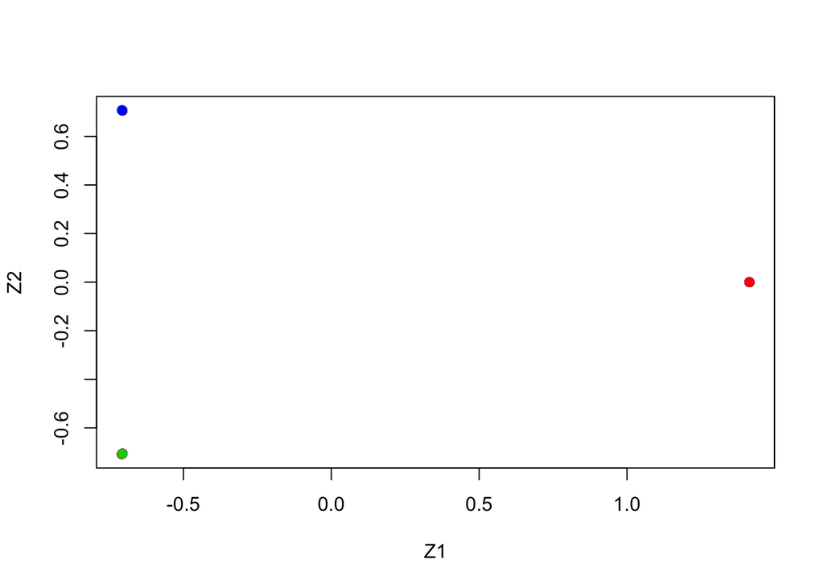

```r
plot(pca.out$x[,1:2], col=2:4,
     xlab="Z1", ylab="Z2", pch=19)
```

3. Perform $K$-means clustering of the observations with $K = 3$. How well do the clusters that you obtained in $K$-means clustering compare to the true class labels? *Hint: You can use the `table()` function in `R` to compare the true class labels to the class labels obtained by clustering. Be careful how you interpret the results: $K$-means clustering will arbitrarily number the clusters, so you cannot simply check whether the true class labels and clustering labels are the same.*

```r
km.out <-  kmeans(x, 3, nstart=20)
table(km.out$cluster, c(rep(1,20), rep(2,20), rep(3,20)))
```

```
##
##      1  2  3
##   1 20  0  0
##   2  0 20  0
##   3  0  0 20
```

**Perfect match.**

4. Perform $K$-means clustering with $K = 2$. Describe your results.

```r
km.out <-  kmeans(x, 2, nstart=20)
km.out$cluster
```

```
##  [1] 1 1 1 1 1 1 1 1 1 1 1 1 1 1 1 1 1 1 1 1 2 2 2 2 2 2 2 2 2 2 2 2 2 2 2
## [36] 2 2 2 2 2 1 1 1 1 1 1 1 1 1 1 1 1 1 1 1 1 1 1 1 1
```

**All of one previous class absorbed into a single class.**

5. Now perform $K$-means clustering with $K = 4$, and describe your results.

```r
km.out <-  kmeans(x, 4, nstart=20)
km.out$cluster
```

```
##  [1] 4 4 4 4 4 1 4 1 4 4 1 1 1 1 4 1 4 1 1 4 2 2 2 2 2 2 2 2 2 2 2 2 2 2 2
## [36] 2 2 2 2 2 3 3 3 3 3 3 3 3 3 3 3 3 3 3 3 3 3 3 3 3
```

**All of one previous cluster split into two clusters.**

6. Now perform $K$-means clustering with $K = 3$ on the first two principal component score vectors, rather than on the raw data. That is, perform $K$-means clustering on the $60 \times 2$ matrix of which the first column is the first principal component score vector, and the second column is the second principal component score vector. Comment on the results.

```r
km.out <-  kmeans(pca.out$x[,1:2], 3, nstart=20)
table(km.out$cluster, c(rep(1,20), rep(2,20), rep(3,20)))
```

```
##
##      1  2  3
##   1  0  0 20
##   2  0 20  0
##   3 20  0  0
```

**Perfect match, once again.**

7. Using the `scale()` function, perform $K$-means clustering with $K = 3$ on the data after scaling each variable to have standard deviation one. How do these results compare to those obtained in (b)? Explain.

```r
km.out <-  kmeans(scale(x), 3, nstart=20)
km.out$cluster
```

```
##  [1] 1 1 1 1 1 3 3 3 2 3 1 3 3 3 1 3 2 3 3 1 2 2 2 2 2 2 2 2 2 2 2 2 3 2 2
## [36] 2 2 2 2 2 1 1 1 3 1 3 1 1 1 3 2 3 3 1 1 3 1 3 3 1
```

**Poorer results than (b): the scaling of the observations effects the distance between them.**

### Exercise 7.3 (Optional)

On the textbook website, www.StatLearning.com, there is a gene expression data set (`Ch10Ex11.csv`) that consists of 40 tissue samples with measurements on 1,000 genes. The first 20 samples are from healthy patients, while the second 20 are from a diseased group.

1. Load in the data using `read.csv()`. You will need to select `header=FALSE`.

```r
data <-  read.csv("http://www-bcf.usc.edu/~gareth/ISL/Ch10Ex11.csv", header=FALSE)
dim(data)
```

```
## [1] 1000   40
```

2. Apply hierarchical clustering to the samples using correlation-based distance, and plot the dendrogram. Do the genes separate the samples into the two groups? Do your results depend on the type of linkage used?

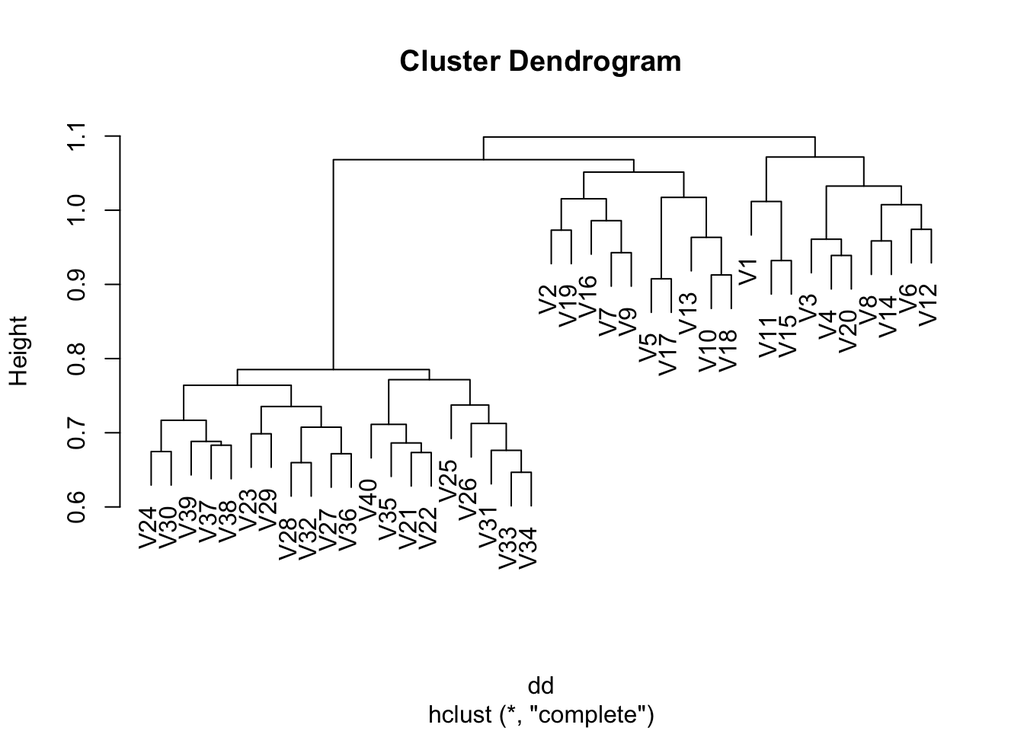

```r
dd <-  as.dist(1 - cor(data))
plot(hclust(dd, method="complete"))
```

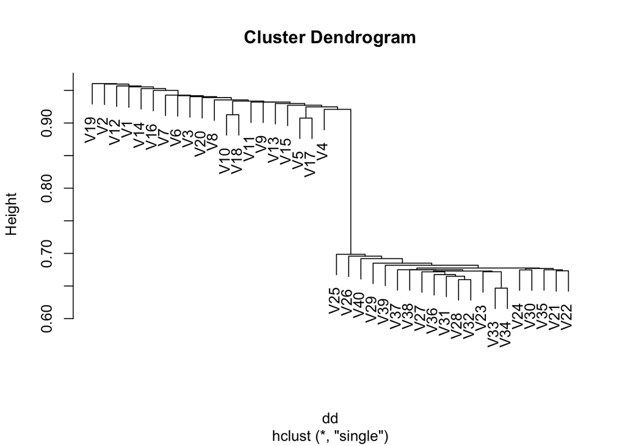

```r
plot(hclust(dd, method="single"))
```

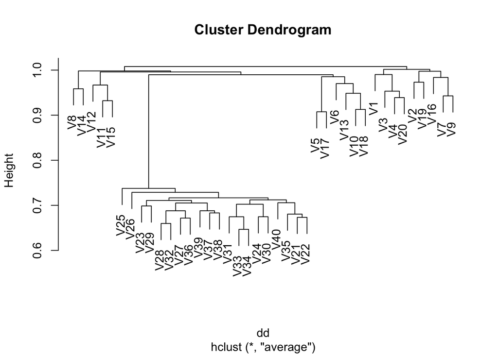

```r
plot(hclust(dd, method="average"))
```

**Two or three groups depending on the linkage method.**

3. Your collaborator wants to know which genes differ the most across the two groups. Suggest a way to answer this question, and apply it here.

**To look at which genes differ the most across the healthy patients and diseased patients, we could look at the loading vectors outputted from PCA to see which genes are used to describe the variance the most.**

```r
pr.out <-  prcomp(t(data))
summary(pr.out)
```

```
## Importance of components:
##                            PC1     PC2     PC3     PC4     PC5     PC6
## Standard deviation     11.9409 6.06818 5.93476 5.83115 5.75209 5.70031
## Proportion of Variance  0.1267 0.03271 0.03129 0.03021 0.02939 0.02887
## Cumulative Proportion   0.1267 0.15939 0.19068 0.22089 0.25029 0.27915
##                            PC7     PC8     PC9    PC10    PC11    PC12
## Standard deviation     5.63448 5.57726 5.54943 5.50625 5.48852 5.46025
## Proportion of Variance 0.02821 0.02764 0.02736 0.02694 0.02676 0.02649
## Cumulative Proportion  0.30736 0.33499 0.36236 0.38929 0.41605 0.44254
##                           PC13    PC14    PC15    PC16    PC17    PC18
## Standard deviation     5.40230 5.33441 5.27756 5.21594 5.20000 5.15140
## Proportion of Variance 0.02593 0.02528 0.02475 0.02417 0.02402 0.02358
## Cumulative Proportion  0.46847 0.49375 0.51850 0.54267 0.56669 0.59027
##                           PC19    PC20    PC21    PC22    PC23    PC24
## Standard deviation     5.11600 5.05591 5.03836 5.01868 4.95965 4.91393
## Proportion of Variance 0.02325 0.02271 0.02255 0.02238 0.02185 0.02145
## Cumulative Proportion  0.61352 0.63623 0.65878 0.68116 0.70301 0.72447
##                           PC25    PC26    PC27    PC28    PC29    PC30
## Standard deviation     4.86397 4.81796 4.80811 4.73485 4.70098 4.65564
## Proportion of Variance 0.02102 0.02062 0.02054 0.01992 0.01963 0.01926
## Cumulative Proportion  0.74548 0.76611 0.78665 0.80656 0.82620 0.84545
##                           PC31    PC32    PC33    PC34    PC35    PC36
## Standard deviation     4.61621 4.56733 4.53032 4.49528 4.36502 4.35858
## Proportion of Variance 0.01893 0.01853 0.01823 0.01795 0.01693 0.01688
## Cumulative Proportion  0.86439 0.88292 0.90115 0.91910 0.93603 0.95291
##                           PC37    PC38    PC39      PC40
## Standard deviation     4.26700 4.20277 4.13922 5.251e-15
## Proportion of Variance 0.01618 0.01569 0.01522 0.000e+00
## Cumulative Proportion  0.96909 0.98478 1.00000 1.000e+00
```

```r
total_load <-  apply(pr.out$rotation, 1, sum)
indices <-  order(abs(total_load), decreasing=TRUE)
indices[1:10]
```

```
##  [1] 865  68 911 428 624  11 524 803 980 822
```

```r
total_load[indices[1:10]]
```

```
##  [1]  0.7765416  0.7137785 -0.7099501 -0.6363706 -0.6195945  0.5885202
##  [7]  0.5583279  0.5535498 -0.5217130  0.4981997
```

**This shows one representation of the top 1% of differing genes.**